# REPORT

HACKATHON

Boutin Maxime, Caurier Grégoire, Hachem Mohamad

2021-12-10 23:20:20

# Operation on the dataset

## Load libraries

```r
library(data.table)
library(rpart)
```

```r
library(ggplot2)
library(RColorBrewer)
library(rattle)
library(caTools)
library(doParallel)
library(mlbench)
library(xgboost)
library(readr)
library(corrplot)
dataset <- read.csv('D:/A4/Machine Learning/Hackaton/data.csv')
head(dataset)
```

```
##   age          job marital           education default housing loan   contact
## 1  60  blue-collar married            basic.9y unknown      no   no telephone
## 2  43   management married professional.course      no     yes   no telephone
## 3  42  blue-collar married            basic.9y      no     yes   no telephone
## 4  29       admin. married         high.school      no     yes   no telephone
## 5  40 entrepreneur married   university.degree      no      no   no telephone
## 6  31   technician  single professional.course      no      no   no  cellular
##   month day_of_week duration campaign pdays previous    poutcome emp.var.rate
## 1   may         mon      301        1   999        0 nonexistent          1.1
## 2   may         mon      134        1   999        0 nonexistent          1.1
## 3   jun         wed      264        2   999        0 nonexistent          1.4
## 4   jun         wed      194        2   999        0 nonexistent          1.4
## 5   may         fri      803        1   999        0 nonexistent          1.1
## 6   aug         thu      231        3   999        0 nonexistent          1.4
##   cons.price.idx cons.conf.idx euribor3m nr.employed   y
## 1         93.994         -36.4     4.857      5191.0  no
## 2         93.994         -36.4     4.857      5191.0  no
## 3         94.465         -41.8     4.864      5228.1  no
## 4         94.465         -41.8     4.864      5228.1  no
## 5         93.994         -36.4     4.859      5191.0 yes
## 6         93.444         -36.1     4.963      5228.1  no
```

##data visualization of the problem

```r
numeric_data = dataset[,c(1,11,12,13,14,16,17,18,19)]

cor(x = numeric_data, use = "everything")
```

```
##                         age     duration     campaign       pdays    previous
## age             1.000000000  0.004829252  0.002867314 -0.03957378  0.02488048
## duration        0.004829252  1.000000000 -0.076987263 -0.05736694  0.02883730
## campaign        0.002867314 -0.076987263  1.000000000  0.05265904 -0.08196969
## pdays          -0.039573785 -0.057366939  0.052659044  1.00000000 -0.57685009
## previous        0.024880484  0.028837304 -0.081969686 -0.57685009  1.00000000
## emp.var.rate   -0.008184156 -0.026484699  0.152239781  0.26835950 -0.42038007
## cons.price.idx -0.008484074  0.004480568  0.130604881  0.07916116 -0.20332486
## cons.conf.idx   0.129680738 -0.001767527 -0.014321403 -0.09848074 -0.04686290
## euribor3m       0.003168499 -0.032012704  0.136449353  0.29278076 -0.45498284
##                emp.var.rate cons.price.idx cons.conf.idx    euribor3m
## age            -0.008184156   -0.008484074   0.129680738  0.003168499
## duration       -0.026484699    0.004480568  -0.001767527 -0.032012704
## campaign        0.152239781    0.130604881  -0.014321403  0.136449353
## pdays           0.268359498    0.079161162  -0.098480740  0.292780759
## previous       -0.420380069   -0.203324861  -0.046862904 -0.454982841
## emp.var.rate    1.000000000    0.778868178   0.175409233  0.971893520
## cons.price.idx  0.778868178    1.000000000   0.040637023  0.690962618
## cons.conf.idx   0.175409233    0.040637023   1.000000000  0.260726787
## euribor3m       0.971893520    0.690962618   0.260726787  1.000000000
```

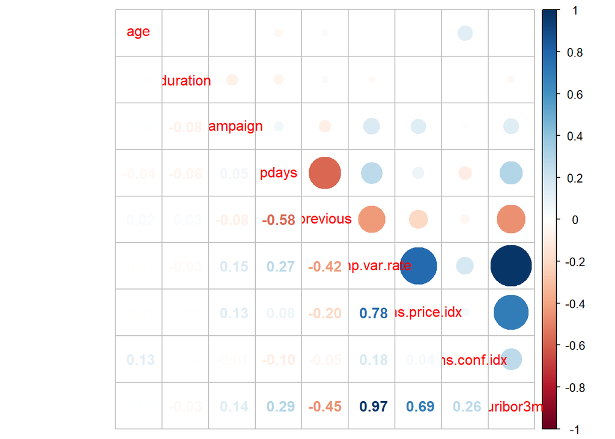

```r
corrplot.mixed(corr = cor(x = numeric_data, use = "everything"))
```

```r
#with this we tried to remove the next variables even if the model was alway the best with all of them
# dataset=dataset[,-16]
# dataset=dataset[,-10]
# dataset=dataset[,-9]
# dataset=dataset[,-8]
# dataset=dataset[,-3]
```

## Put the categorical values as factor

```r
dataset$job=as.factor(dataset$job)
dataset$marital=as.factor(dataset$marital)
dataset$education=as.factor(dataset$education)
dataset$default=as.factor(dataset$default)
dataset$housing=as.factor(dataset$housing)
dataset$loan=as.factor(dataset$loan)
dataset$contact=as.factor(dataset$contact)
dataset$day_of_week=as.factor(dataset$day_of_week)
dataset$poutcome=as.factor(dataset$poutcome)
dataset$y=as.factor(dataset$y)
```

## In order to proceed we will now devide our main data into a training set and a testing set where we will build our models on our training set then check it’s accurancy on our test set. Note : we will set a seed in order to have to same answers.

```r
set.seed(123)
split = sample.split(dataset$y, SplitRatio = 0.66)
traindata = subset(dataset, split == TRUE)
testdata = subset(dataset, split == FALSE)
```

# we will start now by creating our models

#after looking at our data we can conclude that the prediction model that we are trying to build should be a classification model since our final output will be a 1 - 0 / yes - no / the customer will subscribe - no the customer will not subscribe

## Logistic regression

```r
library(caret)
traindata=as.data.frame(traindata)

ctrl <- trainControl(method = "cv", number = 10, repeats=5)
fit.Glm1<- train(y~.,
                 data=traindata,
                 method="glm",

                 trControl = ctrl)
print(fit.Glm1)
```

```
## Generalized Linear Model
##
## 12932 samples
##    20 predictor
##     2 classes: 'no', 'yes'
##
## No pre-processing
## Resampling: Cross-Validated (10 fold)
## Summary of sample sizes: 11638, 11639, 11639, 11638, 11639, 11639, ...
## Resampling results:
##
##   Accuracy  Kappa
##   0.90597   0.4499425
```

```r
print(confusionMatrix(testdata$y,predict(fit.Glm1,testdata),mode = "prec_recall")
)
```

```
## Confusion Matrix and Statistics
##
##           Reference
## Prediction   no  yes
##        no  5731  158
##        yes  410  363
##
##                Accuracy : 0.9147
##                  95% CI : (0.9078, 0.9213)
##     No Information Rate : 0.9218
##     P-Value [Acc > NIR] : 0.984
##
##                   Kappa : 0.5158
##
##  Mcnemar's Test P-Value : <2e-16
##
##               Precision : 0.9732
##                  Recall : 0.9332
##                      F1 : 0.9528
##              Prevalence : 0.9218
##          Detection Rate : 0.8603
##    Detection Prevalence : 0.8840
##       Balanced Accuracy : 0.8150
##
##        'Positive' Class : no
##
```

## Random Forest : In order to Proceed we had no choice but to divide our dataset into a smaller one to perform Random Forest model because it take too much time to perform on the 20 000 lines of the data.

```r
dataset2=dataset[1:3000,]

set.seed(123) # CHANGE THE VALUE OF SEED. PUT YOUR STUDENT'S NUMBER INSTEAD OF 123.
split2 = sample.split(dataset2$y, SplitRatio = 0.66)
traindata2 = subset(dataset2, split2 == TRUE)
testdata2 = subset(dataset2, split2 == FALSE)

traindata2=as.data.frame(traindata2)

library(partykit)
library(randomForest)
set.seed(1)
fit.forest1<- train(y~.,
                    data=traindata2,
                    method="rf",

                    trControl = ctrl)
print(fit.forest1)
```

```
## Random Forest
##
## 1980 samples
##   20 predictor
##    2 classes: 'no', 'yes'
##
## No pre-processing
## Resampling: Cross-Validated (10 fold)
## Summary of sample sizes: 1782, 1782, 1782, 1782, 1782, 1782, ...
## Resampling results across tuning parameters:
##
##   mtry  Accuracy   Kappa
##    2    0.9020202  0.2610346
##   27    0.9101010  0.5200971
##   53    0.9005051  0.4683789
##
## Accuracy was used to select the optimal model using the largest value.
## The final value used for the model was mtry = 27.
```

```r
print(confusionMatrix(testdata2$y,predict(fit.forest1,testdata2),mode = "prec_recall")
)
```

```
## Confusion Matrix and Statistics
##
##           Reference
## Prediction  no yes
##        no  871  36
##        yes  54  59
##
##                Accuracy : 0.9118
##                  95% CI : (0.8927, 0.9285)
##     No Information Rate : 0.9069
##     P-Value [Acc > NIR] : 0.31791
##
##                   Kappa : 0.5186
##
##  Mcnemar's Test P-Value : 0.07314
##
##               Precision : 0.9603
##                  Recall : 0.9416
##                      F1 : 0.9509
##              Prevalence : 0.9069
##          Detection Rate : 0.8539
##    Detection Prevalence : 0.8892
##       Balanced Accuracy : 0.7813
##
##        'Positive' Class : no
##
```

## GBM : same process as random forest

```r
fit.Gboost1<- train(y~.,
                    data=traindata2,
                    method="gbm",

                    trControl = ctrl)
print(fit.Gboost1)
```

```
## Stochastic Gradient Boosting
##
## 1980 samples
##   20 predictor
##    2 classes: 'no', 'yes'
##
## No pre-processing
## Resampling: Cross-Validated (10 fold)
## Summary of sample sizes: 1782, 1782, 1782, 1782, 1782, 1782, ...
## Resampling results across tuning parameters:
##
##   interaction.depth  n.trees  Accuracy   Kappa
##   1                   50      0.9045455  0.3508335
##   1                  100      0.9035354  0.3929905
##   1                  150      0.9065657  0.4429707
##   2                   50      0.9090909  0.4643416
##   2                  100      0.9075758  0.4839364
##   2                  150      0.9121212  0.5051031
##   3                   50      0.9035354  0.4447991
##   3                  100      0.9050505  0.4706605
##   3                  150      0.9111111  0.5077873
##
## Tuning parameter 'shrinkage' was held constant at a value of 0.1
##
## Tuning parameter 'n.minobsinnode' was held constant at a value of 10
## Accuracy was used to select the optimal model using the largest value.
## The final values used for the model were n.trees = 150, interaction.depth =
##  2, shrinkage = 0.1 and n.minobsinnode = 10.
```

```r
print(confusionMatrix(testdata2$y,predict(fit.Gboost1,testdata2),mode = "prec_recall")
)
```

```
## Confusion Matrix and Statistics
##
##           Reference
## Prediction  no yes
##        no  881  26
##        yes  56  57
##
##                Accuracy : 0.9196
##                  95% CI : (0.9012, 0.9356)
##     No Information Rate : 0.9186
##     P-Value [Acc > NIR] : 0.483533
##
##                   Kappa : 0.5383
##
##  Mcnemar's Test P-Value : 0.001362
##
##               Precision : 0.9713
##                  Recall : 0.9402
##                      F1 : 0.9555
##              Prevalence : 0.9186
##          Detection Rate : 0.8637
##    Detection Prevalence : 0.8892
##       Balanced Accuracy : 0.8135
##
##        'Positive' Class : no
##
```

##LDA we also tried to create an LDA model

```r
library(MASS)
classifier.lda <- lda(y~., data=traindata)
classifier.lda
```

```
## Call:
## lda(y ~ ., data = traindata)
##
## Prior probabilities of groups:
##        no       yes
## 0.8840087 0.1159913
##
## Group means:
##          age jobblue-collar jobentrepreneur jobhousemaid jobmanagement
## no  39.99965       0.235042      0.03577677   0.02720434    0.06639258
## yes 41.10133       0.128000      0.02800000   0.02600000    0.06800000
##     jobretired jobself-employed jobservices jobstudent jobtechnician
## no  0.03953814       0.03490203  0.09762071 0.01688244     0.1685619
## yes 0.09400000       0.03333333  0.06466667 0.05400000     0.1706667
##     jobunemployed  jobunknown maritalmarried maritalsingle maritalunknown
## no     0.02388034 0.007872638      0.6187019     0.2681945    0.002011896
## yes    0.03400000 0.010666667      0.5346667     0.3526667    0.004000000
##     educationbasic.6y educationbasic.9y educationhigh.school
## no          0.0613191         0.1508922            0.2291812
## yes         0.0380000         0.1046667            0.2173333
##     educationilliterate educationprofessional.course educationuniversity.degree
## no         0.0004373688                    0.1296361                  0.2887509
## yes        0.0006666667                    0.1373333                  0.3646667
##     educationunknown defaultunknown   defaultyes housingunknown housingyes
## no        0.03840098      0.2206088 0.0001749475     0.02475507  0.5208188
## yes       0.05333333      0.1053333 0.0000000000     0.02466667  0.5400000
##     loanunknown   loanyes contacttelephone  monthaug    monthdec  monthjul
## no   0.02475507 0.1490553        0.3904829 0.1482680 0.002011896 0.1772218
## yes  0.02466667 0.1493333        0.1713333 0.1473333 0.020666667 0.1360000
##      monthjun    monthmar  monthmay  monthnov   monthoct    monthsep
## no  0.1282365 0.008572428 0.3555808 0.1024318 0.01145906 0.008659902
## yes 0.1220000 0.050666667 0.1906667 0.1040000 0.06800000 0.052000000
##     day_of_weekmon day_of_weekthu day_of_weektue day_of_weekwed duration
## no       0.2146606      0.2088873      0.1899930      0.1977782 221.8954
## yes      0.1913333      0.2166667      0.2133333      0.1993333 555.9033
##     campaign    pdays  previous poutcomenonexistent poutcomesuccess
## no  2.619402 984.7588 0.1339223           0.8845346      0.01259622
## yes 2.072667 797.0920 0.5086667           0.6666667      0.18933333
##     emp.var.rate cons.price.idx cons.conf.idx euribor3m nr.employed
## no     0.2375962       93.59971     -40.59927  3.803489    5175.780
```

[output cut: 42 more lines]

```
## day_of_weekmon               -0.0370039540
## day_of_weekthu                0.0302256234
## day_of_weektue                0.0629936332
## day_of_weekwed                0.0821567021
## duration                      0.0029305467
## campaign                      0.0078566227
## pdays                        -0.0008993029
## previous                     -0.0007441360
## poutcomenonexistent           0.2694608503
## poutcomesuccess               1.1079914697
## emp.var.rate                 -1.1589636580
## cons.price.idx                1.7574970427
## cons.conf.idx                 0.0473387080
## euribor3m                     0.1651995364
## nr.employed                   0.0030129237
```

```r
pred.lda = predict(classifier.lda, newdata = testdata[,-21])
cm2 = table(testdata$y,pred.lda$class)
cm2
```

```
##
##         no  yes
##   no  5659  230
##   yes  366  407
```

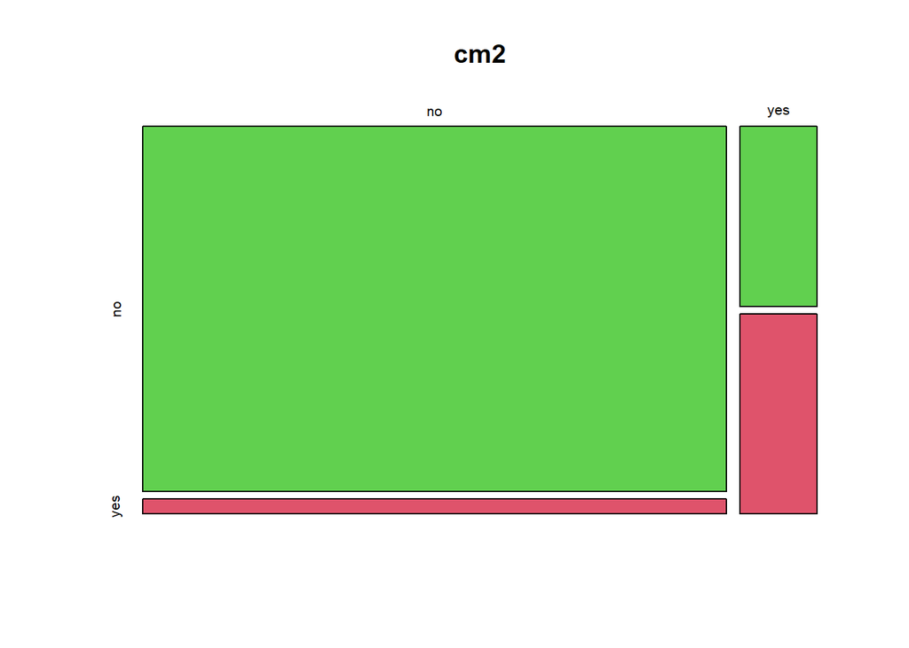

```r
mosaicplot(cm2,col=sample(2:3,2))
```

```r
accuracy2 = (cm2[1,1]+cm2[2,2])/sum(cm2)
accuracy2
```

```
## [1] 0.9105374
```

##Other version of the random Forest

```r
library(randomForest)
random_forest = randomForest(y~., data = traindata2 ,mtry = 3,importance = TRUE, ntrees = 500)
random_forest_pred = predict(random_forest ,newdata =testdata2)
print(confusionMatrix(testdata2$y,predict(random_forest,testdata2,mode = "prec_recall")))
```

```
## Confusion Matrix and Statistics
##
##           Reference
## Prediction  no yes
##        no  877  30
##        yes  62  51
##
##                Accuracy : 0.9098
##                  95% CI : (0.8905, 0.9267)
##     No Information Rate : 0.9206
##     P-Value [Acc > NIR] : 0.906649
##
##                   Kappa : 0.4774
##
##  Mcnemar's Test P-Value : 0.001229
##
##             Sensitivity : 0.9340
##             Specificity : 0.6296
##          Pos Pred Value : 0.9669
##          Neg Pred Value : 0.4513
##              Prevalence : 0.9206
##          Detection Rate : 0.8598
##    Detection Prevalence : 0.8892
##       Balanced Accuracy : 0.7818
##
##        'Positive' Class : no
##
```

## while being in the hackathon we were able to go from a low accurancy to reach a final of 0.92300. to be able to acheive such results we had to take many things into considerations such as the corrolation between the variables, the different classifactionals models, the training data , removing/adding/imporoving variables.

##Best Model

```r
test=read.csv("D:/A4/Machine Learning/Hackaton/test.csv")
test$job=as.factor(test$job)
test$marital=as.factor(test$marital)
test$education=as.factor(test$education)
test$default=as.factor(test$default)
test$housing=as.factor(test$housing)
test$loan=as.factor(test$loan)
test$contact=as.factor(test$contact)
test$day_of_week=as.factor(test$day_of_week)
test$poutcome=as.factor(test$poutcome)



predictions=predict(fit.Glm1,newdata = test)
print(predictions)
```

[output not shown]

[output cut: 42 more lines]

```r
to_be_submitted = data.frame(id=rownames(test), y=predictions)
write.csv(to_be_submitted , file = "D:/A4/Machine Learning/Hackaton/to_be_submitted.csv", row.names = F)
```